# Explore log-ratios with coda4microbiome

Malu Calle and Toni Susin

[figure not shown]

In this document we describe the use of the `explore_logratios()`.

This function explores the association of each log-ratio with a dependent variable (binary or continuous). It summarizes the importance of each variable (taxa) as the aggregation of the association measures of those log-ratios involving the variable. The output includes a plot of the association of the log-ratio with the outcome where the variables (taxa) are ranked by importance.

**Zero imputation**: The algorithm checks whether the data contains zeros and, if so, it implements a simple zero imputation (see the help of `coda4microbiome::impute_zeros()` function). However, the users can impute zeros before using **coda4microbiome** functions with more advanced methods such as those implemented in the R package **zCompositions** (Palarea-Albaladejo and MartinFernandez, 2015)

# 1 explore_logratios for a binary outcome

We illustrate the `explore_logratios` algorithm with the Crohn dataset (included in the package).

**Crohn dataset** includes a matrix, `x_Crohn`, of microbiome compositions at genus level (48 taxa) for 975 individuals from a Crohn’s disease study (662 patients with Crohn’s disease and 313 controls) and an factor variable, `y_Crohn`, indicating if the sample corresponds to a case (CD) or a control (no).

We call function `explore_logratios()` with the default parameters:

```r
library(coda4microbiome)

set.seed(123) # to reproduce the results

data(Crohn, package = "coda4microbiome")   # load the data

Crohn_logratios<-explore_logratios(x=x_Crohn,y=y_Crohn, measure = "glm")
```

The algorithm provides a correlation-like plot that provides the association of each pairwise log-ratios with the outcome. The variables composing the log-ratio are indicated and are ranked according to their aggregated association with the outcome:

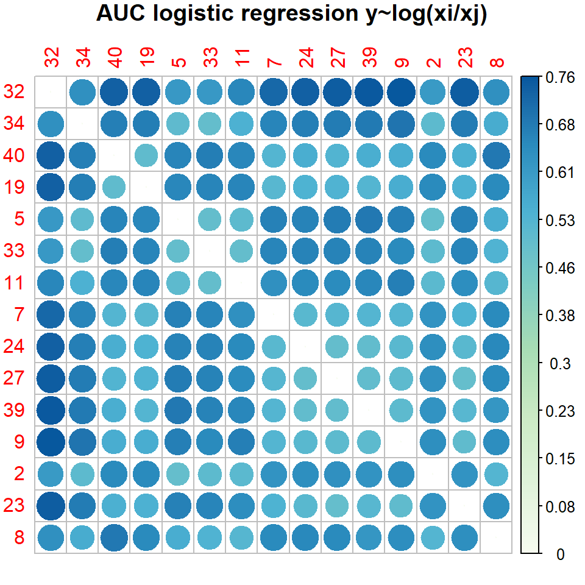

We can see in the plot that the most important variables are 32, 34, 40, 19, ect. This and the name of the variables can be obtained from the output of the function:

```r
Crohn_logratios$`order of importance`
```

```
#>  [1] 32 34 40 19  5 33 11  7 24 27 39  9  2 23  8 28 13 45 35 10 17 42 47 12 20
#> [26] 15 48 37 22  1 14 16 44 41 30 36 38 25  6  3 18 26 31 46 29 21 43  4
```

```r
Crohn_logratios$`name of most important variables`
```

```
#>  [1] "g__Roseburia"                 "o__Clostridiales_g__"
#>  [3] "g__Aggregatibacter"           "g__Dialister"
#>  [5] "f__Peptostreptococcaceae_g__" "g__Lachnospira"
#>  [7] "g__Coprococcus"               "g__Veillonella"
#>  [9] "f__Gemellaceae_g__"           "o__Lactobacillales_g__"
#> [11] "g__Streptococcus"             "g__Eggerthella"
#> [13] "g__Parabacteroides"           "g__Actinomyces"
#> [15] "g__Bacteroides"
```

The output also reports the pair of taxa whose log-ratio is more associated with the outcome:

```r
Crohn_logratios$`max log-ratio`
```

```
#> [1] "32" "9"
```

```r
Crohn_logratios$`names max log-ratio`
```

```
#> [1] "g__Roseburia"   "g__Eggerthella"
```

The algorithm also provide the numerical values behind the correlation plot:

```r
Crohn_logratios$`association log-ratio with y`[1:6,1:6]
```

```
#>           32        34        40        19         5        33
#> 32 0.0000000 0.6348947 0.7387817 0.7369719 0.6115991 0.6145044
#> 34 0.6348947 0.0000000 0.6746257 0.6773356 0.5067180 0.4956855
#> 40 0.7387817 0.6746257 0.0000000 0.5043483 0.6623288 0.6774900
#> 19 0.7369719 0.6773356 0.5043483 0.0000000 0.6603042 0.6619548
#> 5  0.6115991 0.5067180 0.6623288 0.6603042 0.0000000 0.4972757
#> 33 0.6145044 0.4956855 0.6774900 0.6619548 0.4972757 0.0000000
```

# 2 explore_logratios for a continuous outcome

We consider the with the sCD14 dataset (included in the package).

**sCD14 dataset** contains information on the microbiome composition and the inflammatory parameter sCD14 from an HIV study (Noguera-Julian et al. 2016): x_sCD14 is the microbiome abundance matrix for 151 individuals (rows) and 60 genera (columns) and y_sCD14 is a numeric variable with the value of the inflammation parameter sCD14 for each individual.

We call function `explore_logratios()` with the default parameters:

```r
set.seed(123) # to reproduce the results

data(sCD14, package = "coda4microbiome")   # load the data

sCD14_logratios<-explore_logratios(x=x_sCD14,y=y_sCD14, measure = "glm")
```

The algorithm provides a correlation-like plot that provides the association of each pairwise log-ratios with the outcome. The variables composing the log-ratio are indicated and are ranked according to their aggregated association with the outcome:

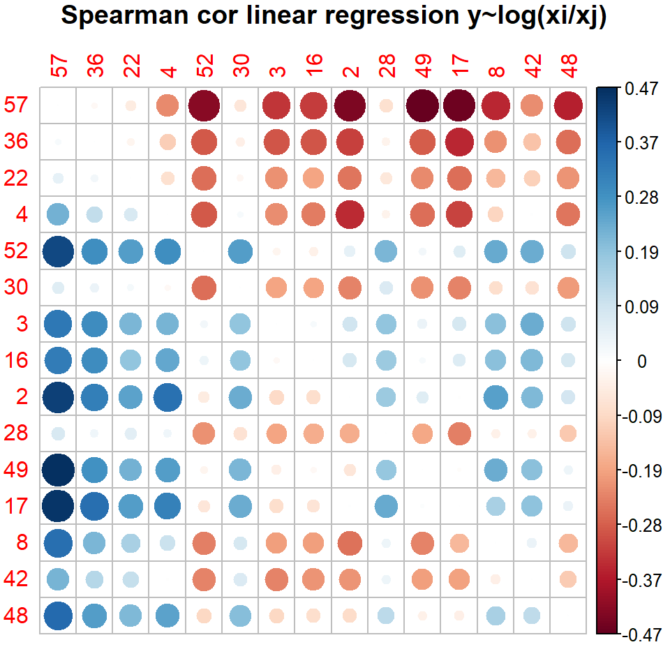

According to the plot and the output of the functions, the most important taxa related sCD14 are:

```r
sCD14_logratios$`order of importance`
```

```
#>  [1] 57 36 22  4 52 30  3 16  2 28 49 17  8 42 48 51 41 35 29 12 47 60 58  7 31
#> [26] 40 20 59 21 14 23 25 55 45 44 15 53 39 37 56 46 18 32 38 43 27 10 11 54 50
#> [51] 24  9 13 26 33  1 19 34  5  6
```

```r
sCD14_logratios$`name of most important variables`
```

```
#>  [1] "g_Collinsella"
#>  [2] "g_Bifidobacterium"
#>  [3] "g_Catenibacterium"
#>  [4] "f_Lachnospiraceae_g_unclassified"
#>  [5] "f_Defluviitaleaceae_g_Incertae_Sedis"
#>  [6] "g_Mitsuokella"
#>  [7] "g_Bacteroides"
#>  [8] "g_Alistipes"
#>  [9] "g_Faecalibacterium"
#> [10] "g_Megasphaera"
#> [11] "g_Thalassospira"
#> [12] "g_Subdoligranulum"
#> [13] "g_Blautia"
#> [14] "g_Streptococcus"
#> [15] "g_Brachyspira"
```

The pair of taxa whose log-ratio is more associated with the sCD14 are:

```r
sCD14_logratios$`max log-ratio`
```

```
#> [1] "57" "49"
```

```r
sCD14_logratios$`names max log-ratio`
```

```
#> [1] "g_Collinsella"   "g_Thalassospira"
```

The correlation values between the log-ratios and sCD14 are:

```r
sCD14_logratios$`association log-ratio with y`[1:6,1:6]
```

```
#>            57          36          22           4         52          30
#> 57 0.00000000 -0.01638891 -0.04805360 -0.22131762 -0.4218543 -0.06132098
#> 36 0.01638891  0.00000000 -0.02449991 -0.11191744 -0.2886977 -0.03776775
#> 22 0.04805360  0.02449991  0.00000000 -0.07662439 -0.2594952 -0.02134678
#> 4  0.22131762  0.11191744  0.07662439  0.00000000 -0.2849224  0.01634477
#> 52 0.42185434  0.28869770  0.25949522  0.28492243  0.0000000  0.25924450
#> 30 0.06132098  0.03776775  0.02134678 -0.01634477 -0.2592445  0.00000000
```